# Biostat 203B Homework 1

Due Jan 26, 2024 @ 11:59PM

Author

Zehan Hu 306329221

## Q1. Git/GitHub

**No handwritten homework reports are accepted for this course.** We work with Git and GitHub. Efficient and abundant use of Git, e.g., frequent and well-documented commits, is an important criterion for grading your homework.

1. Apply for the [Student Developer Pack](https://education.github.com/pack) at GitHub using your UCLA email. You’ll get GitHub Pro account for free (unlimited public and private repositories).
2. Create a **private** repository `biostat-203b-2024-winter` and add `Hua-Zhou` and TA team (`Tomoki-Okuno` for Lec 1; `jonathanhori` and `jasenzhang1` for Lec 80) as your collaborators with write permission.
3. Top directories of the repository should be `hw1`, `hw2`, … Maintain two branches `main` and `develop`. The `develop` branch will be your main playground, the place where you develop solution (code) to homework problems and write up report. The `main` branch will be your presentation area. Submit your homework files (Quarto file `qmd`, `html` file converted by Quarto, all code and extra data sets to reproduce results) in the `main` branch.
4. After each homework due date, course reader and instructor will check out your `main` branch for grading. Tag each of your homework submissions with tag names `hw1`, `hw2`, … Tagging time will be used as your submission time. That means if you tag your `hw1` submission after deadline, penalty points will be deducted for late submission.
5. After this course, you can make this repository public and use it to demonstrate your skill sets on job market.

## Q2. Data ethics training

This exercise (and later in this course) uses the [MIMIC-IV data v2.2](https://physionet.org/content/mimiciv/2.2/), a freely accessible critical care database developed by the MIT Lab for Computational Physiology. Follow the instructions at https://mimic.mit.edu/docs/gettingstarted/ to (1) complete the CITI `Data or Specimens Only Research` course and (2) obtain the PhysioNet credential for using the MIMIC-IV data. Display the verification links to your completion report and completion certificate here. **You must complete Q2 before working on the remaining questions.** (Hint: The CITI training takes a few hours and the PhysioNet credentialing takes a couple days; do not leave it to the last minute.)

Link:

https://www.citiprogram.org/verify/?k00e1566d-2354-4fcd-b6ec-4766f8818c5d-60799375 https://www.citiprogram.org/verify/?w188d6a54-fa9a-4484-b89d-965d83d93c5f-60799375

## Q3. Linux Shell Commands

1. Make the MIMIC v2.2 data available at location `~/mimic`.

```bash
ls -l ~/mimic
```

```
lrwxrwxrwx 1 eewol123 eewol123 32 Feb 27 18:16 /home/eewol123/mimic -> /mnt/d/mimic-iv-2.2/mimic-iv-2.2
```

Refer to the documentation https://physionet.org/content/mimiciv/2.2/ for details of data files. Please, do **not** put these data files into Git; they are big. Do **not** copy them into your directory. Do **not** decompress the gz data files. These create unnecessary big files and are not big-data-friendly practices. Read from the data folder `~/mimic` directly in following exercises.

Use Bash commands to answer following questions.

2. Display the contents in the folders `hosp` and `icu` using Bash command `ls -l`. Why are these data files distributed as `.csv.gz` files instead of `.csv` (comma separated values) files? Read the page https://mimic.mit.edu/docs/iv/ to understand what’s in each folder.

```bash
ls -l ~/mimic/hosp
```

```
total 20248088
-rwxrwxrwx 1 eewol123 eewol123    15516088 Jan 26 00:42 admissions.csv.gz
-rwxrwxrwx 1 eewol123 eewol123  2467761053 Jan 25 21:45 chartevents.csv.gz
-rwxrwxrwx 1 eewol123 eewol123      427468 Jan 26 00:42 d_hcpcs.csv.gz
-rwxrwxrwx 1 eewol123 eewol123      859438 Jan 26 00:42 d_icd_diagnoses.csv.gz
-rwxrwxrwx 1 eewol123 eewol123      578517 Jan 26 00:42 d_icd_procedures.csv.gz
-rwxrwxrwx 1 eewol123 eewol123       12900 Jan 26 00:42 d_labitems.csv.gz
-rwxrwxrwx 1 eewol123 eewol123    25070720 Jan 26 00:42 diagnoses_icd.csv.gz
-rwxrwxrwx 1 eewol123 eewol123     7426955 Jan 26 00:42 drgcodes.csv.gz
-rwxrwxrwx 1 eewol123 eewol123   508524623 Jan 26 00:42 emar.csv.gz
-rwxrwxrwx 1 eewol123 eewol123   471096030 Jan 26 00:42 emar_detail.csv.gz
-rwxrwxrwx 1 eewol123 eewol123     1767138 Jan 26 00:42 hcpcsevents.csv.gz
-rwxrwxrwx 1 eewol123 eewol123 13730083993 Jan 26 00:42 labevents.csv
-rwxrwxrwx 1 eewol123 eewol123  1939088924 Jan 25 21:45 labevents.csv.gz
-rwxrwxrwx 1 eewol123 eewol123    96698496 Jan 26 00:42 microbiologyevents.csv.gz
-rwxrwxrwx 1 eewol123 eewol123    36124944 Jan 26 00:42 omr.csv.gz
-rwxrwxrwx 1 eewol123 eewol123     2312631 Jan 26 00:42 patients.csv.gz
-rwxrwxrwx 1 eewol123 eewol123   398753125 Jan 26 00:42 pharmacy.csv.gz
-rwxrwxrwx 1 eewol123 eewol123   498505135 Jan 26 00:42 poe.csv.gz
-rwxrwxrwx 1 eewol123 eewol123    25477219 Jan 26 00:42 poe_detail.csv.gz
-rwxrwxrwx 1 eewol123 eewol123   458817415 Jan 26 00:43 prescriptions.csv.gz
-rwxrwxrwx 1 eewol123 eewol123     6027067 Jan 26 00:43 procedures_icd.csv.gz
-rwxrwxrwx 1 eewol123 eewol123      122507 Jan 26 00:43 provider.csv.gz
-rwxrwxrwx 1 eewol123 eewol123     6781247 Jan 26 00:43 services.csv.gz
-rwxrwxrwx 1 eewol123 eewol123    36158338 Jan 26 00:43 transfers.csv.gz
```

```bash
ls -l ~/mimic/icu
```

```
total 32574492
-rwxrwxrwx 1 eewol123 eewol123       35893 Jan 26 00:43 caregiver.csv.gz
-rwxrwxrwx 1 eewol123 eewol123 30204420231 Jan 26 00:43 chartevents.csv
-rwxrwxrwx 1 eewol123 eewol123  2467761053 Jan 25 21:45 chartevents.csv.gz
-rwxrwxrwx 1 eewol123 eewol123       57476 Jan 26 00:43 d_items.csv.gz
-rwxrwxrwx 1 eewol123 eewol123    45721062 Jan 26 00:43 datetimeevents.csv.gz
-rwxrwxrwx 1 eewol123 eewol123     2614571 Jan 26 00:43 icustays.csv.gz
-rwxrwxrwx 1 eewol123 eewol123   251962313 Jan 26 00:43 ingredientevents.csv.gz
-rwxrwxrwx 1 eewol123 eewol123   324218488 Jan 26 00:43 inputevents.csv.gz
-rwxrwxrwx 1 eewol123 eewol123    38747895 Jan 26 00:43 outputevents.csv.gz
-rwxrwxrwx 1 eewol123 eewol123    20717852 Jan 26 00:43 procedureevents.csv.gz
```

Because the file in “csv.gz”form is smaller and compressed. So it wont use a lot of storage room

3. Briefly describe what Bash commands `zcat`, `zless`, `zmore`, and `zgrep` do.

zcat: Similar to cat, it displays the contents of gzip-compressed files to the standard output. Useful for viewing compressed text files without decompressing them first.

zless: Works like less, allowing you to page through compressed text files one screen at a time. It’s helpful for reading large compressed files without decompressing them entirely.

zmore: Similar to more, it lets you view compressed files page by page, but with less functionality compared to zless.

zgrep: Combines grep functionality with gzip compression, enabling you to search inside compressed files without decompressing them first.

4. (Looping in Bash) What’s the output of the following bash script?

```bash
for datafile in ~/mimic/hosp/{a,l,pa}*.gz
do
  ls -l $datafile
done
```

```
-rwxrwxrwx 1 eewol123 eewol123 15516088 Jan 26 00:42 /home/eewol123/mimic/hosp/admissions.csv.gz
-rwxrwxrwx 1 eewol123 eewol123 1939088924 Jan 25 21:45 /home/eewol123/mimic/hosp/labevents.csv.gz
-rwxrwxrwx 1 eewol123 eewol123 2312631 Jan 26 00:42 /home/eewol123/mimic/hosp/patients.csv.gz
```

The script will match and list all files in ~/mimic/hosp/ directory that start with ‘a’, ‘l’, or ‘pa’ and end with ‘.gz’. It uses brace expansion to create a list of file patterns to match, namely a*.gz, l*.gz, and pa*.gz.

The output displayed in the image shows three files with their permissions, owner, group, size, modification date, and filename. These files appear to match the pattern specified in the Bash script:

admissions.csv.gz labevents.csv.gz patients.csv.gz Each file is listed with the -l option of ls, which includes long format listing information.

Display the number of lines in each data file using a similar loop. (Hint: combine linux commands `zcat <` and `wc -l`.)

```bash
for datafile in ~/mimic/hosp/{a,l,pa}*.gz
do
  echo "$datafile:"
  zcat "$datafile" | wc -l
done
```

[output not shown]

5. Display the first few lines of `admissions.csv.gz`. How many rows are in this data file? How many unique patients (identified by `subject_id`) are in this data file? Do they match the number of patients listed in the `patients.csv.gz` file? (Hint: combine Linux commands `zcat <`, `head`/`tail`, `awk`, `sort`, `uniq`, `wc`, and so on.)

```bash
zcat ~/mimic/hosp/admissions.csv.gz | head
```

```
subject_id,hadm_id,admittime,dischtime,deathtime,admission_type,admit_provider_id,admission_location,discharge_location,insurance,language,marital_status,race,edregtime,edouttime,hospital_expire_flag
10000032,22595853,2180-05-06 22:23:00,2180-05-07 17:15:00,,URGENT,P874LG,TRANSFER FROM HOSPITAL,HOME,Other,ENGLISH,WIDOWED,WHITE,2180-05-06 19:17:00,2180-05-06 23:30:00,0
10000032,22841357,2180-06-26 18:27:00,2180-06-27 18:49:00,,EW EMER.,P09Q6Y,EMERGENCY ROOM,HOME,Medicaid,ENGLISH,WIDOWED,WHITE,2180-06-26 15:54:00,2180-06-26 21:31:00,0
10000032,25742920,2180-08-05 23:44:00,2180-08-07 17:50:00,,EW EMER.,P60CC5,EMERGENCY ROOM,HOSPICE,Medicaid,ENGLISH,WIDOWED,WHITE,2180-08-05 20:58:00,2180-08-06 01:44:00,0
10000032,29079034,2180-07-23 12:35:00,2180-07-25 17:55:00,,EW EMER.,P30KEH,EMERGENCY ROOM,HOME,Medicaid,ENGLISH,WIDOWED,WHITE,2180-07-23 05:54:00,2180-07-23 14:00:00,0
10000068,25022803,2160-03-03 23:16:00,2160-03-04 06:26:00,,EU OBSERVATION,P51VDL,EMERGENCY ROOM,,Other,ENGLISH,SINGLE,WHITE,2160-03-03 21:55:00,2160-03-04 06:26:00,0
10000084,23052089,2160-11-21 01:56:00,2160-11-25 14:52:00,,EW EMER.,P6957U,WALK-IN/SELF REFERRAL,HOME HEALTH CARE,Medicare,ENGLISH,MARRIED,WHITE,2160-11-20 20:36:00,2160-11-21 03:20:00,0
10000084,29888819,2160-12-28 05:11:00,2160-12-28 16:07:00,,EU OBSERVATION,P63AD6,PHYSICIAN REFERRAL,,Medicare,ENGLISH,MARRIED,WHITE,2160-12-27 18:32:00,2160-12-28 16:07:00,0
10000108,27250926,2163-09-27 23:17:00,2163-09-28 09:04:00,,EU OBSERVATION,P38XXV,EMERGENCY ROOM,,Other,ENGLISH,SINGLE,WHITE,2163-09-27 16:18:00,2163-09-28 09:04:00,0
10000117,22927623,2181-11-15 02:05:00,2181-11-15 14:52:00,,EU OBSERVATION,P2358X,EMERGENCY ROOM,,Other,ENGLISH,DIVORCED,WHITE,2181-11-14 21:51:00,2181-11-15 09:57:00,0
```

```bash
zcat ~/mimic/hosp/admissions.csv.gz | wc -l
```

```
431232
```

```bash
zcat ~/mimic/hosp/patients.csv.gz | cut -d, -f2 | sort | uniq | wc -l
```

```
3
```

6. What are the possible values taken by each of the variable `admission_type`, `admission_location`, `insurance`, and `ethnicity`? Also report the count for each unique value of these variables. (Hint: combine Linux commands `zcat`, `head`/`tail`, `awk`, `uniq -c`, `wc`, and so on; skip the header line.)

```bash
zcat ~/mimic/hosp/admissions.csv.gz | tail -n +2 | cut -d, -f6 | sort | uniq -c
```

```
   6626 AMBULATORY OBSERVATION
  19554 DIRECT EMER.
  18707 DIRECT OBSERVATION
  10565 ELECTIVE
  94776 EU OBSERVATION
 149413 EW EMER.
  52668 OBSERVATION ADMIT
  34231 SURGICAL SAME DAY ADMISSION
  44691 URGENT
```

```bash
zcat ~/mimic/hosp/admissions.csv.gz | tail -n +2 | cut -d, -f8 | sort | uniq -c
```

```
    185 AMBULATORY SURGERY TRANSFER
  10008 CLINIC REFERRAL
 232595 EMERGENCY ROOM
    359 INFORMATION NOT AVAILABLE
   4205 INTERNAL TRANSFER TO OR FROM PSYCH
   5479 PACU
 114963 PHYSICIAN REFERRAL
   7804 PROCEDURE SITE
  35974 TRANSFER FROM HOSPITAL
   3843 TRANSFER FROM SKILLED NURSING FACILITY
  15816 WALK-IN/SELF REFERRAL
```

```bash
zcat ~/mimic/hosp/admissions.csv.gz | tail -n +2 | cut -d, -f10 | sort | uniq -c
```

```
  41330 Medicaid
 160560 Medicare
 229341 Other
```

```bash
zcat ~/mimic/hosp/admissions.csv.gz | tail -n +2 | cut -d, -f13 | sort | uniq -c
```

```
    919 AMERICAN INDIAN/ALASKA NATIVE
   6156 ASIAN
   1198 ASIAN - ASIAN INDIAN
   5587 ASIAN - CHINESE
    506 ASIAN - KOREAN
   1446 ASIAN - SOUTH EAST ASIAN
   2530 BLACK/AFRICAN
  59959 BLACK/AFRICAN AMERICAN
   4765 BLACK/CAPE VERDEAN
   2704 BLACK/CARIBBEAN ISLAND
   7754 HISPANIC OR LATINO
    437 HISPANIC/LATINO - CENTRAL AMERICAN
    639 HISPANIC/LATINO - COLUMBIAN
    500 HISPANIC/LATINO - CUBAN
   4383 HISPANIC/LATINO - DOMINICAN
```

[output cut: 18 more lines]

The admission_type variable in the MIMIC-IV database includes several categories. Some of these are ‘ELECTIVE’, ‘URGENT’, and various types of ‘OBSERVATION’ and ‘EMERGENCY’ admissions.

7. *To compress, or not to compress. That’s the question.* Let’s focus on the big data file `labevents.csv.gz`. Compare compressed gz file size to the uncompressed file size. Compare the run times of `zcat < ~/mimic/labevents.csv.gz | wc -l` versus `wc -l labevents.csv`. Discuss the trade off between storage and speed for big data files. (Hint: `gzip -dk < FILENAME.gz > ./FILENAME`. Remember to delete the large `labevents.csv` file after the exercise.)

```bash
ls -lh ~/mimic/hosp/labevents.csv.gz
```

```
-rwxrwxrwx 1 eewol123 eewol123 1.9G Jan 25 21:45 /home/eewol123/mimic/hosp/labevents.csv.gz
```

```bash
gzip -dk ~/mimic/hosp/labevents.csv.gz
```

```bash
ls -lh ~/mimic/hosp/labevents.csv
```

```
-rwxrwxrwx 1 eewol123 eewol123 13G Jan 26 00:42 /home/eewol123/mimic/hosp/labevents.csv
```

```bash
zcat ~/mimic/hosp/labevents.csv.gz | wc -l
```

[output not shown]

```bash
rm ~/mimic/hosp/labevents.csv.gz
```

Compressed files (gzip) take up significantly less storage space.

Reading from a compressed file (zcat) is generally slower compared to an uncompressed file due to the time needed for decompression. For one-time or infrequent access, zcat is efficient as it saves storage space without needing to store a large uncompressed file. For frequent access to the data, especially random access, keeping an uncompressed version might be more efficient time-wise.

## Q4. Who’s popular in Price and Prejudice

1. You and your friend just have finished reading *Pride and Prejudice* by Jane Austen. Among the four main characters in the book, Elizabeth, Jane, Lydia, and Darcy, your friend thinks that Darcy was the most mentioned. You, however, are certain it was Elizabeth. Obtain the full text of the novel from http://www.gutenberg.org/cache/epub/42671/pg42671.txt and save to your local folder.

```bash
wget -nc http://www.gutenberg.org/cache/epub/42671/pg42671.txt
```

```
File ‘pg42671.txt’ already there; not retrieving.
```

Explain what `wget -nc` does. Do **not** put this text file `pg42671.txt` in Git. Complete the following loop to tabulate the number of times each of the four characters is mentioned using Linux commands.

The wget -nc command is used to download files from the internet. The -nc flag stands for “no-clobber”, which means if a file with the same name already exists in the destination directory, it won’t be overwritten. This is useful for avoiding duplicate downloads or preserving modifications to an existing file.

```bash
wget -nc http://www.gutenberg.org/cache/epub/42671/pg42671.txt
for char in Elizabeth Jane Lydia Darcy
do
  echo $char:
  grep -o $char pg42671.txt | wc -l
done
```

[output not shown]

2. What’s the difference between the following two commands?

```bash
echo 'hello, world' > test1.txt
```

and

```bash
echo 'hello, world' >> test2.txt
```

echo ‘hello, world’ > test1.txt: This command uses the > operator, which redirects the output of the echo command to the file test1.txt. If test1.txt already exists, this command will overwrite the file with the new content (‘hello, world’). If the file doesn’t exist, it will create a new file named test1.txt containing the provided text.

echo ‘hello, world’ >> test2.txt: This command uses the >> operator, which appends the output of the echo command to the file test2.txt. If test2.txt already exists, the text ‘hello, world’ will be added to the end of the file, preserving its existing content. If the file doesn’t exist, it will create a new file named test2.txt with the provided text.

In summary, > is used for overwriting (or creating a new file), while >> is used for appending to an existing file (or creating a new file if it doesn’t exist).

Using `chmod` to make the file executable by the owner, and run

```bash
./middle.sh pg42671.txt 20 5
```

[output not shown]

Explain the output. Explain the meaning of `"$1"`, `"$2"`, and `"$3"` in this shell script. Why do we need the first line of the shell script?

## Q5. More fun with Linux

Try following commands in Bash and interpret the results: `cal`, `cal 2024`, `cal 9 1752` (anything unusual?), `date`, `hostname`, `arch`, `uname -a`, `uptime`, `who am i`, `who`, `w`, `id`, `last | head`, `echo {con,pre}{sent,fer}{s,ed}`, `time sleep 5`, `history | tail`.

```bash
cal
```

```
     March 2024
Su Mo Tu We Th Fr Sa
                1  2
 3  4  5  6  7  8  9
10 11 12 13 14 15 16
17 18 19 20 21 22 23
24 25 26 27 28 29 30
31
```

```bash
cal 2024
```

```
                            2024
      January               February               March
Su Mo Tu We Th Fr Sa  Su Mo Tu We Th Fr Sa  Su Mo Tu We Th Fr Sa
    1  2  3  4  5  6               1  2  3                  1  2
 7  8  9 10 11 12 13   4  5  6  7  8  9 10   3  4  5  6  7  8  9
14 15 16 17 18 19 20  11 12 13 14 15 16 17  10 11 12 13 14 15 16
21 22 23 24 25 26 27  18 19 20 21 22 23 24  17 18 19 20 21 22 23
28 29 30 31           25 26 27 28 29        24 25 26 27 28 29 30
                                            31

       April                  May                   June
Su Mo Tu We Th Fr Sa  Su Mo Tu We Th Fr Sa  Su Mo Tu We Th Fr Sa
    1  2  3  4  5  6            1  2  3  4                     1
 7  8  9 10 11 12 13   5  6  7  8  9 10 11   2  3  4  5  6  7  8
14 15 16 17 18 19 20  12 13 14 15 16 17 18   9 10 11 12 13 14 15
21 22 23 24 25 26 27  19 20 21 22 23 24 25  16 17 18 19 20 21 22
28 29 30              26 27 28 29 30 31     23 24 25 26 27 28 29
                                            30

        July                 August              September
Su Mo Tu We Th Fr Sa  Su Mo Tu We Th Fr Sa  Su Mo Tu We Th Fr Sa
    1  2  3  4  5  6               1  2  3   1  2  3  4  5  6  7
 7  8  9 10 11 12 13   4  5  6  7  8  9 10   8  9 10 11 12 13 14
14 15 16 17 18 19 20  11 12 13 14 15 16 17  15 16 17 18 19 20 21
21 22 23 24 25 26 27  18 19 20 21 22 23 24  22 23 24 25 26 27 28
28 29 30 31           25 26 27 28 29 30 31  29 30


      October               November              December
Su Mo Tu We Th Fr Sa  Su Mo Tu We Th Fr Sa  Su Mo Tu We Th Fr Sa
       1  2  3  4  5                  1  2   1  2  3  4  5  6  7
 6  7  8  9 10 11 12   3  4  5  6  7  8  9   8  9 10 11 12 13 14
13 14 15 16 17 18 19  10 11 12 13 14 15 16  15 16 17 18 19 20 21
20 21 22 23 24 25 26  17 18 19 20 21 22 23  22 23 24 25 26 27 28
27 28 29 30 31        24 25 26 27 28 29 30  29 30 31
```

```bash
cal 9 1752
```

```
   September 1752
Su Mo Tu We Th Fr Sa
       1  2 14 15 16
17 18 19 20 21 22 23
24 25 26 27 28 29 30
```

```bash
date
```

```
Fri Mar 22 16:45:41 PDT 2024
```

```bash
hostname
```

```
LENOVOY7000p
```

```bash
arch
```

```
x86_64
```

```bash
uname -a
```

```
Linux LENOVOY7000p 5.10.16.3-microsoft-standard-WSL2 #1 SMP Fri Apr 2 22:23:49 UTC 2021 x86_64 x86_64 x86_64 GNU/Linux
```

```bash
uptime
```

```
 16:45:41 up  1:11,  0 users,  load average: 0.18, 0.21, 0.18
```

```bash
who am i
```

```bash
who
```

```bash
w
```

```
 16:45:41 up  1:11,  0 users,  load average: 0.18, 0.21, 0.18
USER     TTY      FROM             LOGIN@   IDLE   JCPU   PCPU WHAT
```

```bash
id
```

```
uid=1000(eewol123) gid=1000(eewol123) groups=1000(eewol123),4(adm),20(dialout),24(cdrom),25(floppy),27(sudo),29(audio),30(dip),44(video),46(plugdev),116(netdev)
```

```bash
last | head
```

```
reboot   system boot  5.10.16.3-micros Fri Feb  9 13:58   still running

wtmp begins Fri Feb  9 13:58:27 2024
```

```bash
echo {con,pre}{sent,fer}{s,ed}
```

```
consents consented confers confered presents presented prefers prefered
```

```bash
time sleep 5
```

```
real    0m5.001s
user    0m0.001s
sys 0m0.000s
```

```bash
history | tail
```

## Q6. Book

1. Git clone the repository https://github.com/christophergandrud/Rep-Res-Book for the book *Reproducible Research with R and RStudio* to your local machine.
2. Open the project by clicking `rep-res-3rd-edition.Rproj` and compile the book by clicking `Build Book` in the `Build` panel of RStudio. (Hint: I was able to build `git_book` and `epub_book` but not `pdf_book`.)

The point of this exercise is (1) to get the book for free and (2) to see an example how a complicated project such as a book can be organized in a reproducible way.

For grading purpose, include a screenshot of Section 4.1.5 of the book here.

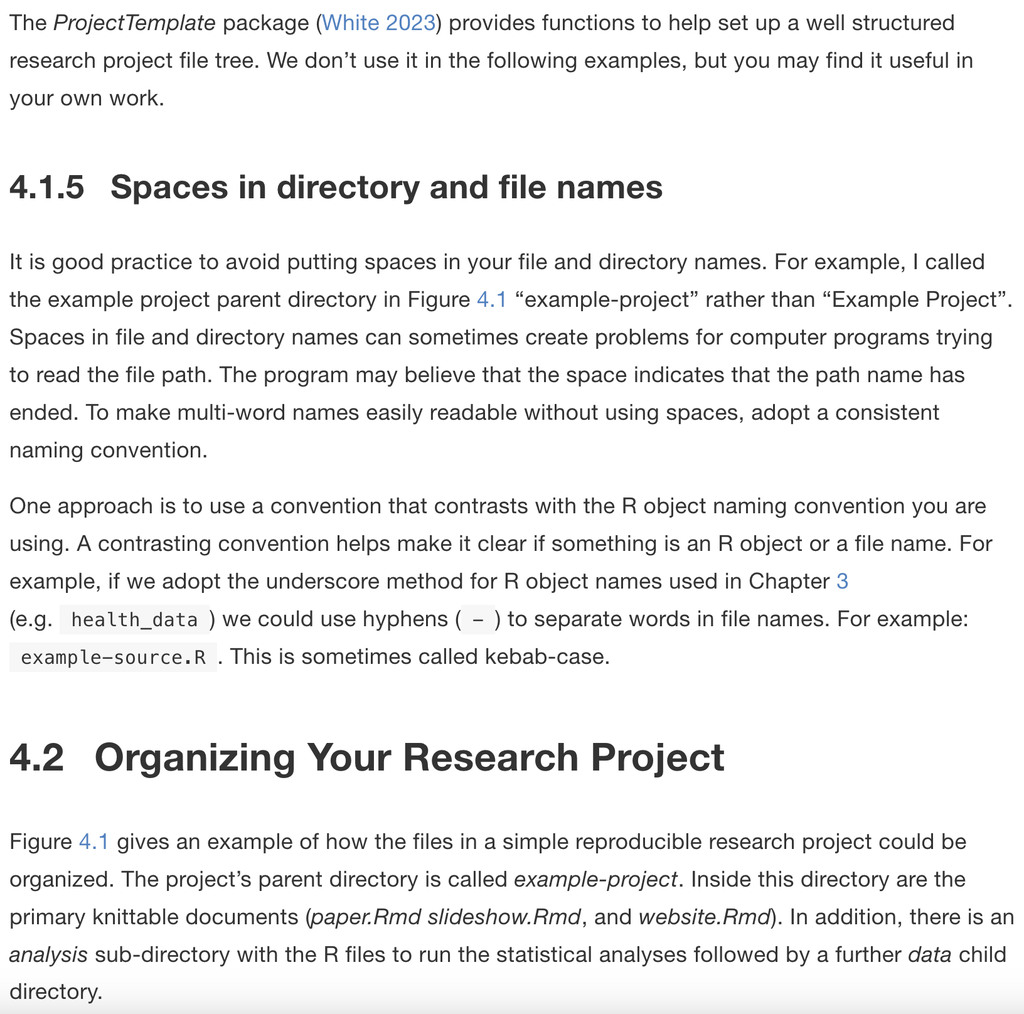